# BikeShare Analysis 2019

Harvey Morris

2024-09-04

## Scenario

Cyclistic’s finance analysts have concluded that annual members are much more profitable than casual riders. Although the pricing flexibility helps Cyclistic attract more customers, Moreno believes that maximizing the number of annual members will be key to future growth.

Rather than creating a marketing campaign that targets all-new customers, Moreno believes there is a solid opportunity to convert casual riders into members. She notes that casual riders are already aware of the Cyclistic program and have chosen Cyclistic for their mobility needs.

Moreno has set a clear goal: Design marketing strategies aimed at converting casual riders into annual members. In order to do that, however, the team needs to better understand how annual members and casual riders differ, why casual riders would buy a membership, and how digital media could affect their marketing tactics. Moreno and her team are interested in analyzing the Cyclistic historical bike trip data to identify trends.

Three questions will guide the future marketing program: 1. How do annual members and casual riders use Cyclistic bikes differently? 2. Why would casual riders buy Cyclistic annual memberships? 3. How can Cyclistic use digital media to influence casual riders to become members?

**Moreno has assigned you the first question to answer: How do annual members and casual riders use Cyclistic bikes differently?**

Business Goal: Design marketing strategies aimed at converting casual riders into annual members.

**Analysis Goal: How do annual members and casual riders use Cyclistic bikes differently?**

# Preparation

Data Licence: https://divvybikes.com/data-license-agreement

I start by accessing the data located at https://divvy-tripdata.s3.amazonaws.com/index.html and downloading the 4 csv files for each quarter of 2019. I established that the files have hundreds of thousands of rows and spreadsheet software will not be efficient and R will be used for cleaning and analysis. My next task is to create clear file name convention and foldering for ease of use and then upload the data to R

```r
Trips_2019_Q1 <- read.csv("Trips_2019_Q1.csv")
Trips_2019_Q2 <- read.csv("Trips_2019_Q2.csv")
Trips_2019_Q3 <- read.csv("Trips_2019_Q3.csv")
Trips_2019_Q4 <- read.csv("Trips_2019_Q4.csv")
```

# Cleaning

Firstly we need to install the R package “tidyverse” to use the data analysis tools in this package. All dataframes contain 12 columns in the same order but Q2 column names are not in the same format so we rename them to follow the same format.

```r
library(tidyverse)
colnames (Trips_2019_Q2) <- colnames (Trips_2019_Q1)
```

Now all 4 dataframes are in a postion to be cleaned ready for analysis, here is a preview of the data in Trips_2019_Q1

```
## Rows: 365,069
## Columns: 12
## $ trip_id           <int> 21742443, 21742444, 21742445, 21742446, 21742447, 21…
## $ start_time        <chr> "2019-01-01 00:04:37", "2019-01-01 00:08:13", "2019-…
## $ end_time          <chr> "2019-01-01 00:11:07", "2019-01-01 00:15:34", "2019-…
## $ bikeid            <int> 2167, 4386, 1524, 252, 1170, 2437, 2708, 2796, 6205,…
## $ tripduration      <chr> "390.0", "441.0", "829.0", "1,783.0", "364.0", "216.…
## $ from_station_id   <int> 199, 44, 15, 123, 173, 98, 98, 211, 150, 268, 299, 2…
## $ from_station_name <chr> "Wabash Ave & Grand Ave", "State St & Randolph St", …
## $ to_station_id     <int> 84, 624, 644, 176, 35, 49, 49, 142, 148, 141, 295, 4…
## $ to_station_name   <chr> "Milwaukee Ave & Grand Ave", "Dearborn St & Van Bure…
## $ usertype          <chr> "Subscriber", "Subscriber", "Subscriber", "Subscribe…
## $ gender            <chr> "Male", "Female", "Female", "Male", "Male", "Female"…
## $ birthyear         <int> 1989, 1990, 1994, 1993, 1994, 1983, 1984, 1990, 1995…
```

I will create 4 new dataframes of cleaned data, separate from the originals removing empty/NA fields. I also decided upon removing any observations with ages over 90 years old. I then formatted the tripduration column in to a numeric column as the comma separating the thousands will cause errors in later analysis. Finally I split the start_time column in to 2 new columns for date and hour for later analysis. This code chunk for cleaning was carried out in the same way for each quarter.

```r
Q1_clean <- drop_na(Trips_2019_Q1, usertype, gender, birthyear) %>%
  filter(birthyear >=1929)
    Q1_clean$start_time <- as_datetime(Q1_clean$start_time)
      Q1_clean$tripduration <- as.numeric(gsub(",", "", Q1_clean$tripduration))
        Q1_clean$start_date <- date(Q1_clean$start_time)
          Q1_clean$start_hour <- format(Q1_clean$start_time, format = "%H")
```

Now with 4 cleaned dataframes, I will combine them all to get the full data in to one table “Year_2019” and create another column for the weekday the bike was used

```r
H1_2019 <- full_join(Q1_clean, Q2_clean)
```

[output not shown]

```r
    H2_2019 <- full_join(Q3_clean, Q4_clean)
```

[output not shown]

```r
      Year_2019 <- full_join(H1_2019, H2_2019)
```

[output not shown]

```r
        rm (H1_2019,H2_2019)
Year_2019 <- Year_2019 %>%
  mutate(start_day = weekdays(Year_2019$start_date)
  )
```

This data frame now holds over 3.25 million observations.

# Analyse

To find some key data on how annual members and casual riders use the bikes differently I wanted to look at extracting insights for comparison on the following:

- **How does the age groups compare for casuals and subscribers?**
- **How does the ride duration compare for casuals and subscribers?**
- **What days of the week do users and casuals use the bikes?**
- **What time of day do casuals and subscribers use the bikes?**
- **What stations are most frequently used by casual and subscribers?**

I will create 2 new columns for analysis, one grouping the users by age and another grouping the duration of the rides. I will also find the averages of the trip duration and ages of the users, as well as the most popular start and end stations for both user types.

```r
# Creating an age group column in the newly abbreviated 'df'
df <- Year_2019 %>%
  mutate(
    age_group = dplyr::case_when(
      birthyear >= 2001            ~ "< 18",
        birthyear <= 2000 & birthyear >= 1995 ~ "19-24",
        birthyear <= 1994 & birthyear >= 1985 ~ "25-34",
        birthyear <= 1984 & birthyear >= 1975 ~ "35-44",
        birthyear <= 1974 & birthyear >= 1965 ~ "45-54",
        birthyear <= 1964 & birthyear >= 1955 ~ "55-64",
        birthyear < 1955                 ~ "65 +"
    ),
    age_group = factor(
      age_group,
      level = c("< 18", "19-24", "25-34", "35-44", "45-54", "55-64", "65 +")
    )
  )
# Removing the now duplicate dataframe 'Year_2019' = 'df'
rm(Year_2019)
# Creating a ride time column for analysis
df <- df %>%
  mutate(
    duration_group = dplyr::case_when(
      tripduration <= 600           ~ "<10min",
      tripduration >= 601 & tripduration <= 1800 ~ "10-30min",
      tripduration >= 1801 & tripduration <= 3600 ~ "30min-1hr",
      tripduration >= 3601 & tripduration <= 7200 ~ "1-2hr",
      tripduration >= 7201 & tripduration <= 10800 ~ "2-3hr",
      tripduration > 10800                 ~ "3hr+"
    ),
    duration_group = factor(
      duration_group,
      level = c("<10min", "10-30min", "30min-1hr", "1-2hr", "2-3hr", "3hr+")
    )
  )
# Organising the ride start day so weekdays are in order of weekday rather than alphabetically
df$start_day <- as.factor(df$start_day)
  df$start_day = factor(df$start_day, levels = c('Monday','Tuesday',
    'Wednesday', 'Thursday', 'Friday', 'Saturday', 'Sunday'))
```

#### Finding the average ride duration for each user type

```
## # A tibble: 2 × 2
##   usertype   avg_ride_mins
##   <chr>              <dbl>
## 1 Customer            49.0
## 2 Subscriber          14.3
```

#### Finding the average age of each user type

```
## # A tibble: 2 × 2
##   usertype   avg_age
##   <chr>        <dbl>
## 1 Customer      30.9
## 2 Subscriber    35.4
```

# Share

Now I have analysed the data I can share my findings through some visualisations and key findings.

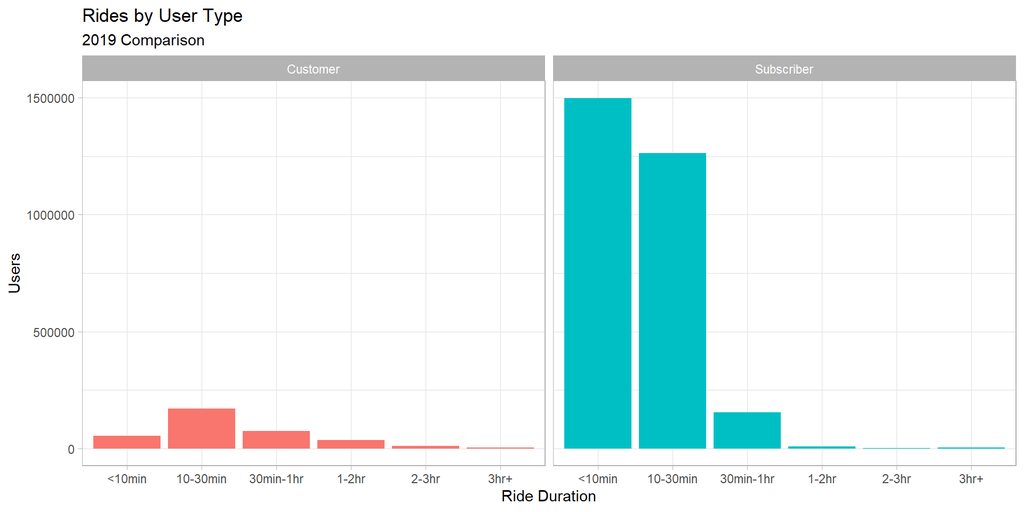

#### The average ride time for a customer is 49 minutes. The average ride time for a subscriber is 14 minutes.

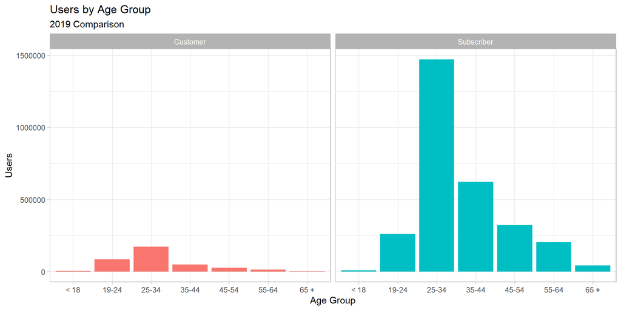

#### The average age of a customer is 31 and the average age of a subscriber is 35

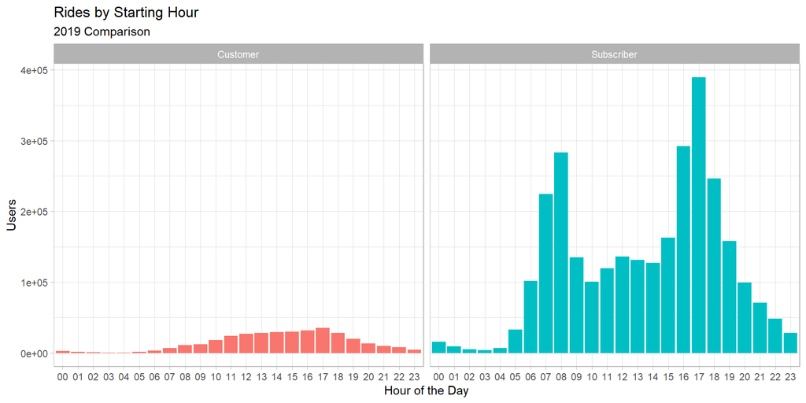

#### Subscribers have high useage of bikes during 7am and 8am in the morning and 4pm - 6pm whereas customers have a gradual increase and steady demand during daylight hours.

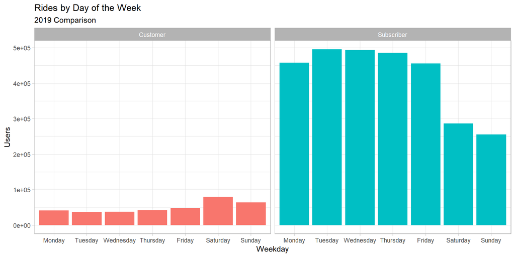

```
## # A tibble: 5 × 4
##   from_station_name         to_station_name           usertype most_popular
##   <chr>                     <chr>                     <chr>           <int>
## 1 Lake Shore Dr & Monroe St Streeter Dr & Grand Ave   Customer         2029
## 2 Streeter Dr & Grand Ave   Streeter Dr & Grand Ave   Customer         1838
## 3 Lake Shore Dr & Monroe St Lake Shore Dr & Monroe St Customer         1453
## 4 Michigan Ave & Oak St     Michigan Ave & Oak St     Customer         1290
## 5 Streeter Dr & Grand Ave   Millennium Park           Customer         1013
```

#### The top 5 most used docking stations by *customers* are located at parks, the pier and beaches.

```
## # A tibble: 5 × 4
##   from_station_name            to_station_name             usertype most_popular
##   <chr>                        <chr>                       <chr>           <int>
## 1 Canal St & Adams St          Michigan Ave & Washington … Subscri…         3538
## 2 Michigan Ave & Washington St Clinton St & Washington Bl… Subscri…         2776
## 3 Columbus Dr & Randolph St    Clinton St & Washington Bl… Subscri…         2638
## 4 Michigan Ave & Washington St Canal St & Adams St         Subscri…         2537
## 5 Canal St & Madison St        Michigan Ave & Washington … Subscri…         2328
```

#### The top 5 most used docking stations by *subscribers* are located near to train stations.

# Act

Based on the analysis, it is evident that casual riders tend to use bikes for longer durations compared to subscribers. This is particularly prominent on weekends, where casual riders are more likely to be having leisurely rides, exploring parts of the city such as parks and beaches. This contrasts with subscribers, who typically use bikes for shorter trips, likely reflecting their use of the service for commuting or other routine activities.

Given the analysis, the following are my top three recommendations to help convert customers in to subscribers.

1. **Enhance availability in recreational areas**: Given that casual riders are drawn to areas with parks, beaches, and outdoor activities, it would be beneficial to increase bike availability and docking stations in these zones, particularly on weekends. This can help meet the higher demand from casual users who seek leisure rides in these popular areas.
2. **Introduce flexible pricing options for casual riders**: Since casual riders tend to use bikes for longer periods, introducing variations on the annual pass, such as weekend passes with discounts for extended use, we could encourage more usage. This pricing model would cater to the needs of casual riders while still ensuring profitability for the service.
3. **Tailored marketing campaigns**: Marketing efforts for casual riders could promote bike routes that highlight scenic areas, parks and beaches and could attract more users, especially on weekends.

By reviewing this analysis, the marketing team can better cater to the distinct preference of casual riders and in turn convert more customers in to subscribers.